# IODS course project

## Method

The cross-correlation table drawn with ggplot shows that biggest correlation coefficients exist between variables Points and Attitude (.437) as well as a negative correlation between variables of deep and surface learning (-0.324). Some interesting differences in the distributions can be observed by gender in the variables of Attitude and surface learning. These would require further statistical examination, which is not in the scope of this paper.

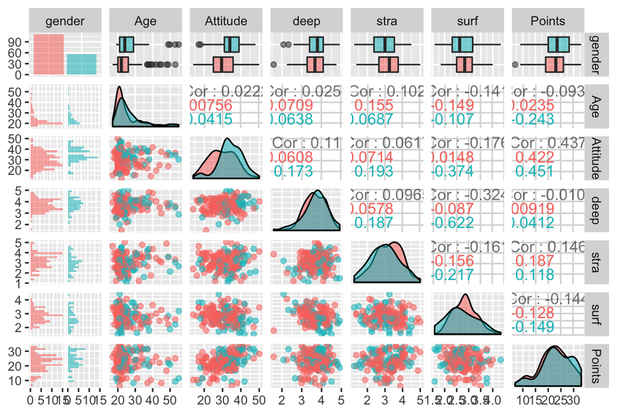

```r
pic <- ggpairs(students2014, mapping = aes(col = gender, alpha = 0.3), lower = list(combo = wrap("facethist", bins = 20)))
pic
```

Next, a multiple linear regression was used to investigate the relationship between learning styles and final exam points. Based on the cross-correlation table three variables were selected for the first model: attitude, strategic learning and surface learning (the last of which was expected to have a negative effect)

```r
model1 <- lm(Points ~ Attitude + stra + surf, data = students2014)
summary(model1)
```

```
##
## Call:
## lm(formula = Points ~ Attitude + stra + surf, data = students2014)
##
## Residuals:
##      Min       1Q   Median       3Q      Max
## -17.1550  -3.4346   0.5156   3.6401  10.8952
##
## Coefficients:
##             Estimate Std. Error t value Pr(>|t|)
## (Intercept) 11.01711    3.68375   2.991  0.00322 **
## Attitude     0.33952    0.05741   5.913 1.93e-08 ***
## stra         0.85313    0.54159   1.575  0.11716
## surf        -0.58607    0.80138  -0.731  0.46563
## ---
## Signif. codes:  0 '***' 0.001 '**' 0.01 '*' 0.05 '.' 0.1 ' ' 1
##
## Residual standard error: 5.296 on 162 degrees of freedom
## Multiple R-squared:  0.2074, Adjusted R-squared:  0.1927
## F-statistic: 14.13 on 3 and 162 DF,  p-value: 3.156e-08
```

```r
model2 <- lm(Points ~ Attitude + stra, data = students2014)
summary(model2)
```

```
##
## Call:
## lm(formula = Points ~ Attitude + stra, data = students2014)
##
## Residuals:
##      Min       1Q   Median       3Q      Max
## -17.6436  -3.3113   0.5575   3.7928  10.9295
##
## Coefficients:
##             Estimate Std. Error t value Pr(>|t|)
## (Intercept)  8.97290    2.39591   3.745  0.00025 ***
## Attitude     0.34658    0.05652   6.132 6.31e-09 ***
## stra         0.91365    0.53447   1.709  0.08927 .
## ---
## Signif. codes:  0 '***' 0.001 '**' 0.01 '*' 0.05 '.' 0.1 ' ' 1
##
## Residual standard error: 5.289 on 163 degrees of freedom
## Multiple R-squared:  0.2048, Adjusted R-squared:  0.1951
## F-statistic: 20.99 on 2 and 163 DF,  p-value: 7.734e-09
```

In Model 2 the postiive effect of attitude to final exam points remains (p<.001). In this model also strategic learning styles shows a positive effect over exam success (p<0.1). However, the explanatory power of the model is still very low, adjusted R-squared 0.20.

Finally, three diagnostic plots were produced to explore the validity of the model: Residuals vs Fitted values, Normal QQ-plot, and Residuals vs Leverage.

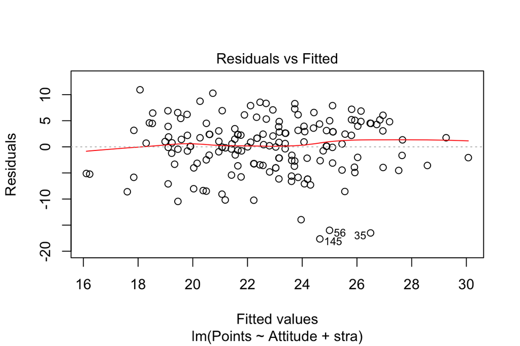

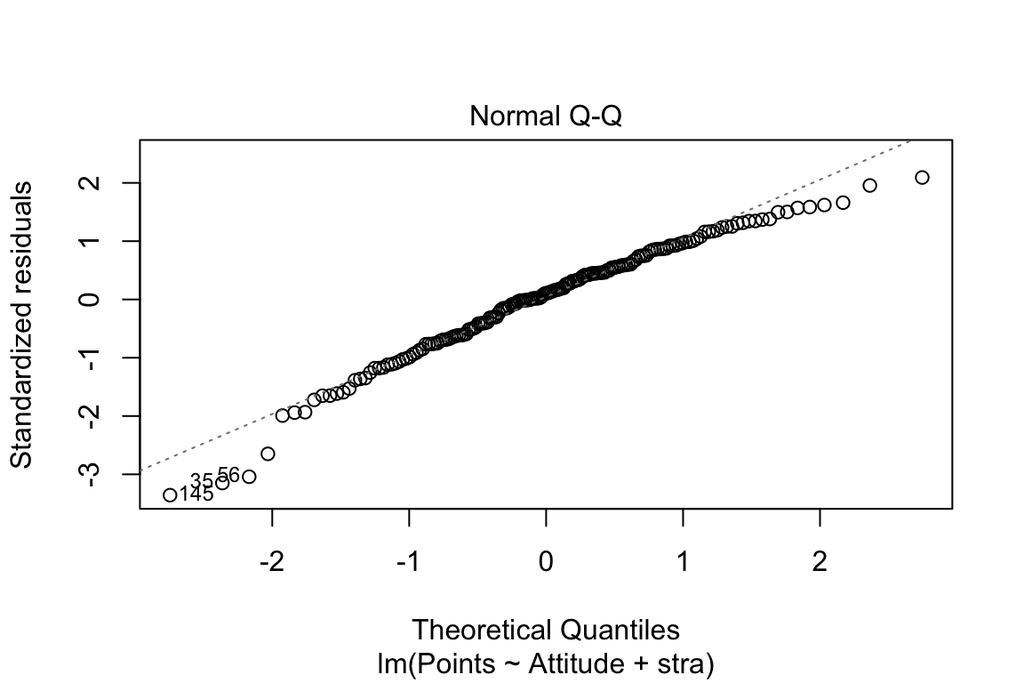

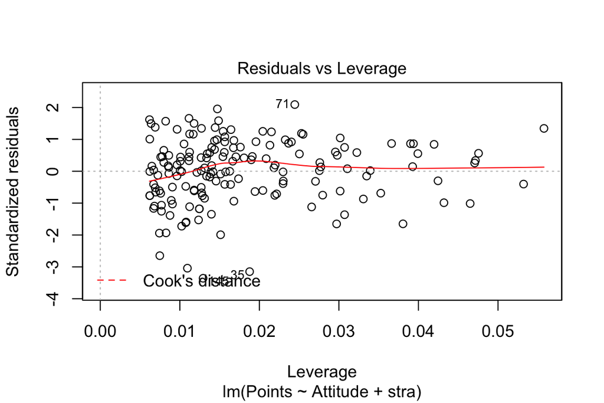

```r
plot(model2, which = c(1, 2, 5))
```

First, regression analysis assumes that the size of errors in the model should not be dependent on the independent variables. The scatter plot of **residuals vs. fitted values** shows that the errors have a constant variance as no pattern is found in the plot apart from a few outliners in the middle.

Second, the **QQ plot** implies that the errors of the model follow a linear line reasonably well, showing that the errors are normally distributed.

Hence, to conclude, all assumptions required for a regression analysis to be valid are met with this dataset and Model 2.

## Conclusion

Nevertheless, based on this investigation, a practical conclusion would be: **learn to love statistics to get better grades**!

# Chapter 3: Playing out with logistic regression analysis

Again starting off by loading all the packages needed for this analysis

```r
library(dplyr)
library(ggplot2)
library(GGally)
library(tidyr)
```

## Data

The dataset at hand is Student Alcohol Consumption Data Set, (see [1] and [data information](https://archive.ics.uci.edu/ml/datasets/STUDENT+ALCOHOL+CONSUMPTION#)). The original survey data is collected on two different classes in two high schools. For this study the data from two different surveys were combined: from mathematics class and from portugese class. Only the students who participated the survey on both classes were included in the analysis, by joining the two datasetss using the background variables. The final dataset includes 382 respondents and 35 variables, listed below in Table 1.

```r
# Table 1
alc <- read.csv("data/alc_final.csv", row.names = 1, header=TRUE)
colnames(alc)
```

```
##  [1] "school"     "sex"        "age"        "address"    "famsize"
##  [6] "Pstatus"    "Medu"       "Fedu"       "Mjob"       "Fjob"
## [11] "reason"     "nursery"    "internet"   "guardian"   "traveltime"
## [16] "studytime"  "failures"   "schoolsup"  "famsup"     "paid"
## [21] "activities" "higher"     "romantic"   "famrel"     "freetime"
## [26] "goout"      "Dalc"       "Walc"       "health"     "absences"
## [31] "G1"         "G2"         "G3"         "alc_use"    "high_use"
```

The purpose of this analysis is to study the predictors of high/low alcohol consumption. High alcohol comsumption is defined as taking more then 2 portions on average per week. We start the exploration with the following set of hypotheses.

**H1. Number of school absenses predicts high alcohol consumption.**

**H2. Number of past class failures predicts high alcohol consumption**

**H3. Higher reported value in going out with friends predicts high alcohol consumption.**

**H4. Male gender predicts high alcohol consumption.**

```r
selected_columns <- c("sex","absences","failures","goout","high_use")
alc_sel <- select(alc, one_of(selected_columns))
```

## Distributions

First lets investigate the distributions of the variables using gather and ggplot. To be honest I’m not sure why the gather-function is needed here.

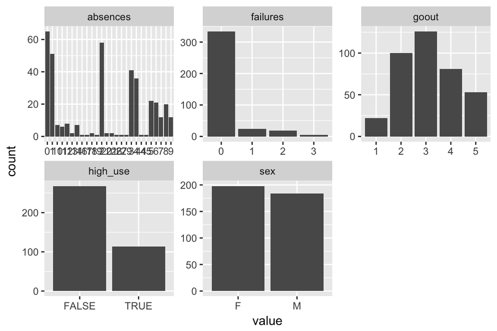

```r
gather(alc_sel) %>% ggplot(aes(value)) + facet_wrap("key", scales = "free") + geom_bar()
```

Next, the selected variables are compared to the variable that classifies the students who take over two doses of alcohol per week as high users of alcohol.

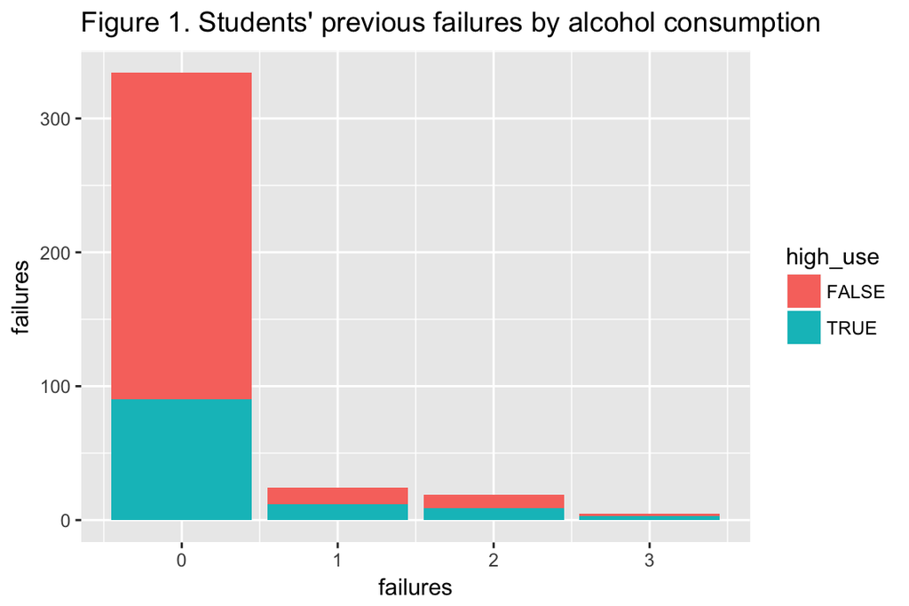

```r
fig1 <- ggplot(alc_sel, aes(x = failures, fill = high_use))
fig1 + geom_bar() + ylab("failures") + ggtitle("Figure 1. Students' previous failures by alcohol consumption")
```

Figure 1 shows students’ previous course failures by alcohol consumption. The distribution is heavily biased towards zero. It is difficult to make any conclusion based on the figure only. Majority of the non-failed student are not high users of alcohol, however.

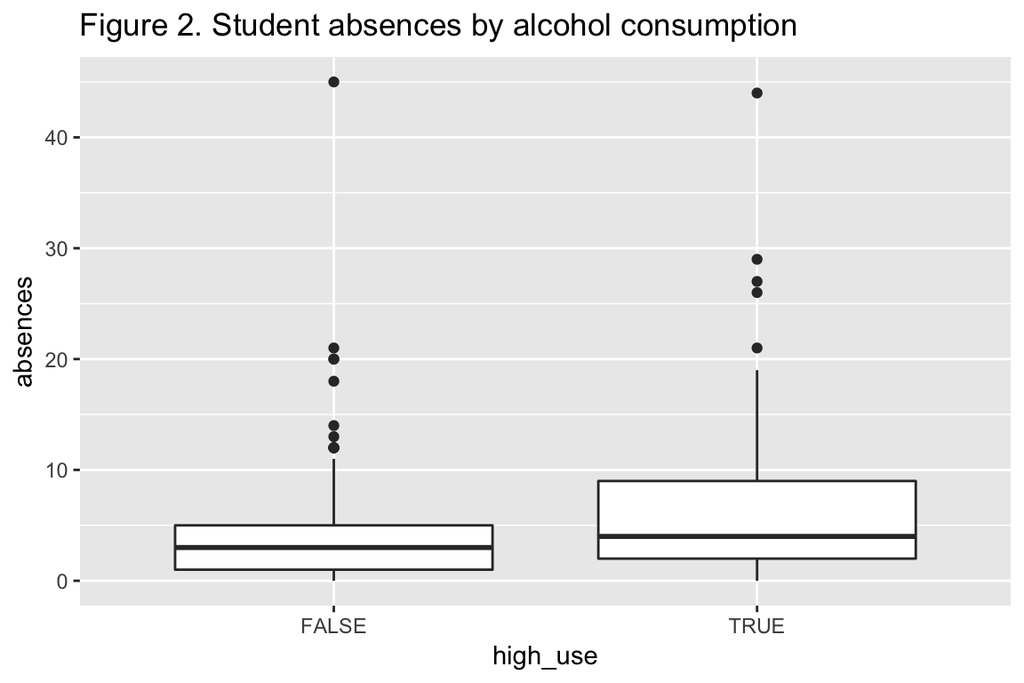

```r
fig2 <- ggplot(alc, aes(x = high_use, y = absences))
fig2 + geom_boxplot() + ylab("absences") + ggtitle("Figure 2. Student absences by alcohol consumption")
```

Figure 2 shows student absences by alcohol consumption. We can observe that high users of alcohol have larger numbers of absences.

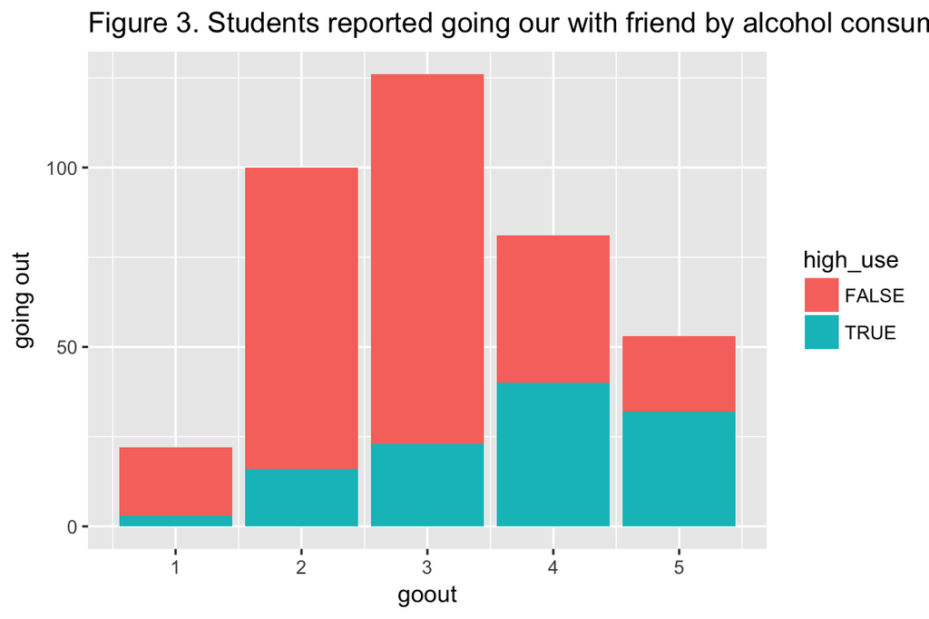

```r
fig3 <- ggplot(alc_sel, aes(x = goout, fill = high_use))
fig3 + geom_bar() + ylab("going out") + ggtitle("Figure 3. Students reported going our with friend by alcohol consumption")
```

Figure 3 shows students’ reported going our with friend by alcohol consumption. It looks like students who are high-users of alcohol are also going out more with their friends. The majority of respondents report going moderately out.

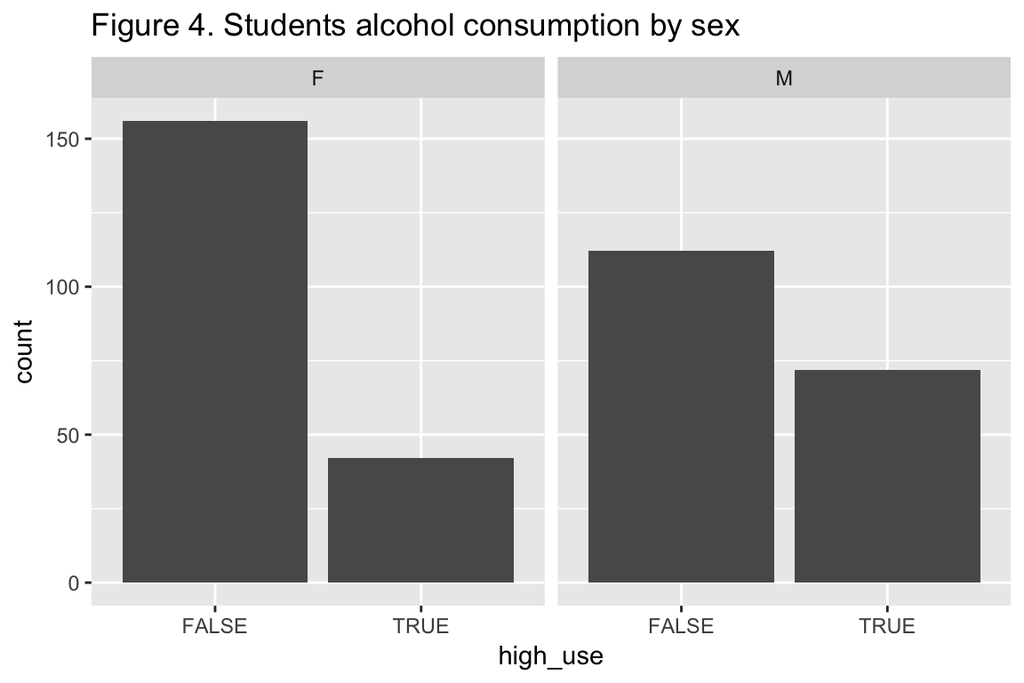

```r
fig4 <- ggplot(data = alc, aes(x = high_use))
fig4 + geom_bar() + facet_wrap("sex") + ggtitle("Figure 4. Students alcohol consumption by sex")
```

Figure 4 shows the distributions or high and low alcohol users by gender. We can observe that in males there are more high users in numbers and also proportionally.

Based on these graps it is reasonable to proceed with these variables. The only exception is previous failures, which is difficult to interpret from the plot.

## Method

In order to test the hypotheses logistic regression was used.

```r
# fit the model
m1 <- glm(high_use ~ goout + failures + absences + sex, data = alc, family = "binomial")
summary(m1)
```

```
##
## Call:
## glm(formula = high_use ~ goout + failures + absences + sex, family = "binomial",
##     data = alc)
##
## Deviance Residuals:
##     Min       1Q   Median       3Q      Max
## -2.0299  -0.7890  -0.5417   0.7857   2.3588
##
## Coefficients:
##             Estimate Std. Error z value Pr(>|z|)
## (Intercept) -4.13390    0.47292  -8.741  < 2e-16 ***
## goout        0.70797    0.11998   5.901 3.62e-09 ***
## failures     0.34560    0.21093   1.638 0.101330
## absences     0.08243    0.02235   3.688 0.000226 ***
## sexM         0.91999    0.25625   3.590 0.000330 ***
## ---
## Signif. codes:  0 '***' 0.001 '**' 0.01 '*' 0.05 '.' 0.1 ' ' 1
##
## (Dispersion parameter for binomial family taken to be 1)
##
##     Null deviance: 465.68  on 381  degrees of freedom
## Residual deviance: 385.06  on 377  degrees of freedom
## AIC: 395.06
##
## Number of Fisher Scoring iterations: 4
```

```r
# compute odds ratios confidence intervals
oddra <- coef(m1) %>% exp
coin <- confint(m1) %>% exp
cbind(oddra, coin)
```

```
##                  oddra       2.5 %     97.5 %
## (Intercept) 0.01602022 0.006086805 0.03902357
## goout       2.02986872 1.613471240 2.58531654
## failures    1.41283378 0.934759890 2.14797583
## absences    1.08592493 1.040580166 1.13727912
## sexM        2.50925591 1.526894419 4.17886012
```

The regression model confirms that three of the four variables are significant in predicting high alcohol use: absences, going out with friends, and male sex. Hence, hypotheses H1, H3 and H4 can be accepted. H2, however, suggested that previous course failures would predict high alcohol use. H2 must be rejected.

Odd rations for all explanatory variables are positive. Students who go out with friends are two times more likely to drink high dosages of alcohol, and male student 2,5 times more likely to drink high dosages. The effect of absences is only slightly above one at 1,09, but the confidence intervals nevertheless remain above one. Hence the positive effect is small but it exists.

For the final model the non-significant predictor of failures is removed.

```r
# fit the new model
m2 <- glm(high_use ~ goout + absences + sex, data = alc, family = "binomial")
summary(m2)
```

```
##
## Call:
## glm(formula = high_use ~ goout + absences + sex, family = "binomial",
##     data = alc)
##
## Deviance Residuals:
##     Min       1Q   Median       3Q      Max
## -1.7871  -0.8153  -0.5446   0.8357   2.4740
##
## Coefficients:
##             Estimate Std. Error z value Pr(>|z|)
## (Intercept) -4.16317    0.47506  -8.764  < 2e-16 ***
## goout        0.72981    0.11970   6.097 1.08e-09 ***
## absences     0.08418    0.02237   3.764 0.000167 ***
## sexM         0.95872    0.25459   3.766 0.000166 ***
## ---
## Signif. codes:  0 '***' 0.001 '**' 0.01 '*' 0.05 '.' 0.1 ' ' 1
##
## (Dispersion parameter for binomial family taken to be 1)
##
##     Null deviance: 465.68  on 381  degrees of freedom
## Residual deviance: 387.75  on 378  degrees of freedom
## AIC: 395.75
##
## Number of Fisher Scoring iterations: 4
```

```r
# compute odds ratios confidence intervals
oddra <- coef(m2) %>% exp
coin <- confint(m2) %>% exp
cbind(oddra, coin)
```

```
##                  oddra       2.5 %     97.5 %
## (Intercept) 0.01555815 0.005885392 0.03804621
## goout       2.07468346 1.650182481 2.64111050
## absences    1.08782902 1.042458467 1.13933894
## sexM        2.60835292 1.593132148 4.33151387
```

Next let’s use the model to predict future values.

```r
# predict() the probability of high_use
probabilities <- predict(m2, type = "response")
alc_sel <- mutate(alc_sel, probability = probabilities)
alc_sel <- mutate(alc_sel, prediction = probability > 0.5)
table(high_use = alc_sel$high_use, prediction = alc_sel$prediction)
```

```
##         prediction
## high_use FALSE TRUE
##    FALSE   253   15
##    TRUE     65   49
```

Hence with this model in the current data set we result with 65 and 15 incorrectly classified students - stupid datapoints who are not following the model!

```r
# a plot of high_use versus probability, prediction as colors
# g <- ggplot(alc_sel, aes(x = probability, y = high_use, col = prediction))
# g + geom_point()
# OMITTING THE PLOT BECAUSE I DON'T FIND IT VERY USEFUL OR ILLUMINATING

# tabulate the target variable versus the predictions
table(high_use = alc_sel$high_use, prediction = alc_sel$prediction) %>% prop.table() %>% addmargins()
```

```
##         prediction
## high_use      FALSE       TRUE        Sum
##    FALSE 0.66230366 0.03926702 0.70157068
##    TRUE  0.17015707 0.12827225 0.29842932
##    Sum   0.83246073 0.16753927 1.00000000
```

```r
# ripping the loss function from datacamp
loss_func <- function(class, prob) {
  n_wrong <- abs(class - prob) > 0.5 # sijoitta 1 n_wrongiin jos oik pätee eli kun arvaus meni pieleen
  mean(n_wrong)
}

# call loss_func to compute the average probablity proportion of wrong predictions in the (training) data
loss_func(class = alc_sel$high_use, prob = alc_sel$probability)
```

```
## [1] 0.2094241
```

This computed average proportion of incorrect predictions means that approximately 20 % of the predictions were incorrect following model m2. This training error is lower than the error achieved e.g. by guessing all students to be low-use alcohol consumers (29%). Hence the performance of the model is not perfect but better than a random guess. More variable testing would be needed to make the model more accurate.

```r
# K-fold cross-validation
library(boot)
cv <- cv.glm(data = alc_sel, cost = loss_func, glmfit = m2, K = 10)

# average number of wrong predictions in the cross validation
cv$delta[1]
```

```
## [1] 0.2120419
```

Performing a 10-fold cross validation for the model shows that the mean prediction error also for testing data is pretty close to the original training error.

### References:

[1]. P. Cortez and A. Silva. Using Data Mining to Predict Secondary School Student Performance. In A. Brito and J. Teixeira Eds., Proceedings of 5th FUture BUsiness TEChnology Conference (FUBUTEC 2008) pp. 5-12, Porto, Portugal, April, 2008, EUROSIS, ISBN 978-9077381-39-7.

# Chapter 4: Clustering and classification

Again starting off by loading all the packages needed for this analysis

```r
# access the MASS package and load the data
library(MASS)
```

```r
library(dplyr)
library(ggplot2)
library(GGally)
data("Boston")
```

## Data

The dataset used in these analysis describes housing values in the suburbs of Boston. It is freely availble in the MASS package ([more information here](https://stat.ethz.ch/R-manual/R-devel/library/MASS/html/Boston.html)).

The dataset has 506 observations and 14 columns.

```r
# explore data dimension and structures
dim(Boston)
```

```
## [1] 506  14
```

```r
str(Boston)
```

```
## 'data.frame':    506 obs. of  14 variables:
##  $ crim   : num  0.00632 0.02731 0.02729 0.03237 0.06905 ...
##  $ zn     : num  18 0 0 0 0 0 12.5 12.5 12.5 12.5 ...
##  $ indus  : num  2.31 7.07 7.07 2.18 2.18 2.18 7.87 7.87 7.87 7.87 ...
##  $ chas   : int  0 0 0 0 0 0 0 0 0 0 ...
##  $ nox    : num  0.538 0.469 0.469 0.458 0.458 0.458 0.524 0.524 0.524 0.524 ...
##  $ rm     : num  6.58 6.42 7.18 7 7.15 ...
##  $ age    : num  65.2 78.9 61.1 45.8 54.2 58.7 66.6 96.1 100 85.9 ...
##  $ dis    : num  4.09 4.97 4.97 6.06 6.06 ...
##  $ rad    : int  1 2 2 3 3 3 5 5 5 5 ...
##  $ tax    : num  296 242 242 222 222 222 311 311 311 311 ...
##  $ ptratio: num  15.3 17.8 17.8 18.7 18.7 18.7 15.2 15.2 15.2 15.2 ...
##  $ black  : num  397 397 393 395 397 ...
##  $ lstat  : num  4.98 9.14 4.03 2.94 5.33 ...
##  $ medv   : num  24 21.6 34.7 33.4 36.2 28.7 22.9 27.1 16.5 18.9 ...
```

```r
summary(Boston)
```

```
##       crim                zn             indus            chas
##  Min.   : 0.00632   Min.   :  0.00   Min.   : 0.46   Min.   :0.00000
##  1st Qu.: 0.08204   1st Qu.:  0.00   1st Qu.: 5.19   1st Qu.:0.00000
##  Median : 0.25651   Median :  0.00   Median : 9.69   Median :0.00000
##  Mean   : 3.61352   Mean   : 11.36   Mean   :11.14   Mean   :0.06917
##  3rd Qu.: 3.67708   3rd Qu.: 12.50   3rd Qu.:18.10   3rd Qu.:0.00000
##  Max.   :88.97620   Max.   :100.00   Max.   :27.74   Max.   :1.00000
##       nox               rm             age              dis
##  Min.   :0.3850   Min.   :3.561   Min.   :  2.90   Min.   : 1.130
##  1st Qu.:0.4490   1st Qu.:5.886   1st Qu.: 45.02   1st Qu.: 2.100
##  Median :0.5380   Median :6.208   Median : 77.50   Median : 3.207
##  Mean   :0.5547   Mean   :6.285   Mean   : 68.57   Mean   : 3.795
##  3rd Qu.:0.6240   3rd Qu.:6.623   3rd Qu.: 94.08   3rd Qu.: 5.188
##  Max.   :0.8710   Max.   :8.780   Max.   :100.00   Max.   :12.127
##       rad              tax           ptratio          black
##  Min.   : 1.000   Min.   :187.0   Min.   :12.60   Min.   :  0.32
##  1st Qu.: 4.000   1st Qu.:279.0   1st Qu.:17.40   1st Qu.:375.38
##  Median : 5.000   Median :330.0   Median :19.05   Median :391.44
##  Mean   : 9.549   Mean   :408.2   Mean   :18.46   Mean   :356.67
##  3rd Qu.:24.000   3rd Qu.:666.0   3rd Qu.:20.20   3rd Qu.:396.23
##  Max.   :24.000   Max.   :711.0   Max.   :22.00   Max.   :396.90
##      lstat            medv
##  Min.   : 1.73   Min.   : 5.00
##  1st Qu.: 6.95   1st Qu.:17.02
##  Median :11.36   Median :21.20
##  Mean   :12.65   Mean   :22.53
##  3rd Qu.:16.95   3rd Qu.:25.00
##  Max.   :37.97   Max.   :50.00
```

Next, let’s use pairs to get a graphical overview of the data. It seems that there are some variables seem to correlate positively or negatively, however not necessarily linear. In this analysis we are interested in the crime rates in particular. In the graph it seems that certain variables are heavile clustered based on low or high crime rates, such as chad (Charles River dummy variable), rad (index of accessibility to radial highways), tax rate and the proportion of blacks by town. However, some statistical analysis is required to show if this perception is actually true.

[figure not shown]

```r
# graphical overview of the data
pairs(Boston)
```

Next, let’s standardize the dataset for the LDA analysis. Scaling subtracts the column means from the corresponding columns and divides the difference with standard deviation. We end up having variables that all have a mean of zero.

```r
# center and standardize variables
boston_scaled <- scale(Boston)
summary(boston_scaled)
```

```
##       crim                 zn               indus
##  Min.   :-0.419367   Min.   :-0.48724   Min.   :-1.5563
##  1st Qu.:-0.410563   1st Qu.:-0.48724   1st Qu.:-0.8668
##  Median :-0.390280   Median :-0.48724   Median :-0.2109
##  Mean   : 0.000000   Mean   : 0.00000   Mean   : 0.0000
##  3rd Qu.: 0.007389   3rd Qu.: 0.04872   3rd Qu.: 1.0150
##  Max.   : 9.924110   Max.   : 3.80047   Max.   : 2.4202
##       chas              nox                rm               age
##  Min.   :-0.2723   Min.   :-1.4644   Min.   :-3.8764   Min.   :-2.3331
##  1st Qu.:-0.2723   1st Qu.:-0.9121   1st Qu.:-0.5681   1st Qu.:-0.8366
##  Median :-0.2723   Median :-0.1441   Median :-0.1084   Median : 0.3171
##  Mean   : 0.0000   Mean   : 0.0000   Mean   : 0.0000   Mean   : 0.0000
##  3rd Qu.:-0.2723   3rd Qu.: 0.5981   3rd Qu.: 0.4823   3rd Qu.: 0.9059
##  Max.   : 3.6648   Max.   : 2.7296   Max.   : 3.5515   Max.   : 1.1164
##       dis               rad               tax             ptratio
##  Min.   :-1.2658   Min.   :-0.9819   Min.   :-1.3127   Min.   :-2.7047
##  1st Qu.:-0.8049   1st Qu.:-0.6373   1st Qu.:-0.7668   1st Qu.:-0.4876
##  Median :-0.2790   Median :-0.5225   Median :-0.4642   Median : 0.2746
##  Mean   : 0.0000   Mean   : 0.0000   Mean   : 0.0000   Mean   : 0.0000
##  3rd Qu.: 0.6617   3rd Qu.: 1.6596   3rd Qu.: 1.5294   3rd Qu.: 0.8058
##  Max.   : 3.9566   Max.   : 1.6596   Max.   : 1.7964   Max.   : 1.6372
##      black             lstat              medv
##  Min.   :-3.9033   Min.   :-1.5296   Min.   :-1.9063
##  1st Qu.: 0.2049   1st Qu.:-0.7986   1st Qu.:-0.5989
##  Median : 0.3808   Median :-0.1811   Median :-0.1449
##  Mean   : 0.0000   Mean   : 0.0000   Mean   : 0.0000
##  3rd Qu.: 0.4332   3rd Qu.: 0.6024   3rd Qu.: 0.2683
##  Max.   : 0.4406   Max.   : 3.5453   Max.   : 2.9865
```

```r
boston_scaled <- as.data.frame(boston_scaled) #otherwise its matrix
```

## Linear Discriminant Analysis LDA

Next, we generate a new categorial variable of the crime variable (crim) by using the quantiles (quartiles) as break points. This new variable replaces the continuous crime variable in the dataset.

```r
# save the scaled crim as scaled_crim
scaled_crim <- boston_scaled$crim
# create a quantile vector of crim and print it
bins <- quantile(scaled_crim)
# create a categorical variable 'crime'
crime <- cut(scaled_crim, breaks = bins, include.lowest = TRUE, label=c("low", "med_low", "med_high", "high"))
# remove original crim from the dataset
boston_scaled <- dplyr::select(boston_scaled, -crim)
# add the new categorical value to scaled data
boston_scaled <- data.frame(boston_scaled, crime)
```

Next, for the purposes of the following analysis, the dataset is divided to training and testing sets, so that 80% of the data belongs to the training set.

```r
n <- nrow(boston_scaled) # gives number of rows
# choose randomly 80% of the rows
ind <- sample(n,  size = n * 0.8)
# create training and testing sets
train <- boston_scaled[ind,]
test <- boston_scaled[-ind,]
```

Next, we fit a linear discriminant analysis model on the training dataset, trying to predict the categorical crime variable using all other variables as predictors.

```r
lda.fit <- lda(crime ~ ., data = train)
lda.fit
```

```
## Call:
## lda(crime ~ ., data = train)
##
## Prior probabilities of groups:
##       low   med_low  med_high      high
## 0.2277228 0.2623762 0.2599010 0.2500000
##
## Group means:
##                  zn      indus        chas        nox          rm
## low       0.9088301 -0.9404441 -0.05835623 -0.8904016  0.48498236
## med_low  -0.1037730 -0.2672707  0.02481057 -0.5250964 -0.15046501
## med_high -0.3965857  0.2303203  0.17762524  0.3955747  0.03492235
## high     -0.4872402  1.0171306 -0.03844192  1.0564058 -0.30886042
##                 age        dis        rad        tax     ptratio
## low      -0.9294495  0.7774052 -0.6922578 -0.7215427 -0.48354009
## med_low  -0.2144728  0.2641921 -0.5419867 -0.4494916 -0.03698102
## med_high  0.4440120 -0.3959310 -0.4284195 -0.2968345 -0.19589640
## high      0.7736222 -0.8414123  1.6379981  1.5139626  0.78062517
##                black       lstat        medv
## low       0.38029892 -0.80812766  0.58641074
## med_low   0.32256693 -0.06621909 -0.02141514
## med_high  0.07436153  0.05997289  0.09511828
## high     -0.78792100  0.82466955 -0.62774112
##
## Coefficients of linear discriminants:
##                 LD1          LD2         LD3
## zn       0.12449015  0.742348126 -0.86959309
## indus    0.05073420 -0.355172595  0.25521729
## chas    -0.08169070 -0.015653490  0.11935247
## nox      0.38589538 -0.663987821 -1.52322501
## rm      -0.09831754 -0.018098096 -0.16890604
## age      0.26651470 -0.427154176  0.09749152
## dis     -0.05806370 -0.326448329  0.19871086
## rad      3.20671668  0.773745862  0.13604362
## tax     -0.07333150  0.217480245  0.45266006
## ptratio  0.13434402  0.006388985 -0.32970806
## black   -0.11685409  0.016406741  0.17799814
## lstat    0.20076789 -0.120726245  0.36845209
## medv     0.18055513 -0.257746435 -0.27015210
##
## Proportion of trace:
##    LD1    LD2    LD3
## 0.9451 0.0422 0.0127
```

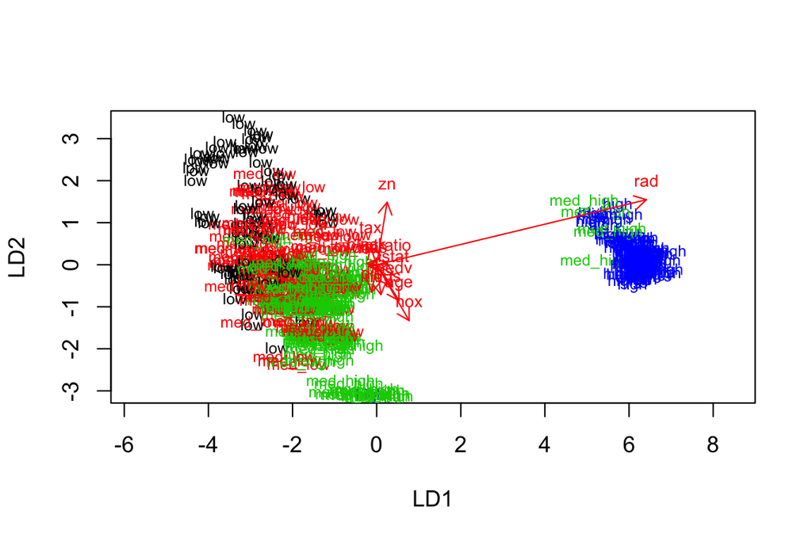

```r
# the function for lda biplot arrows
# original? http://stackoverflow.com/questions/17232251/how-can-i-plot-a-biplot-for-lda-in-r
lda.arrows <- function(x, myscale = 1, arrow_heads = 0.1, color = "red", tex = 0.75, choices = c(1,2)){
  heads <- coef(x)
  arrows(x0 = 0, y0 = 0,
         x1 = myscale * heads[,choices[1]],
         y1 = myscale * heads[,choices[2]], col=color, length = arrow_heads)
  text(myscale * heads[,choices], labels = row.names(heads),
       cex = tex, col=color, pos=3)
}

# target classes as numeric
classes <- as.numeric(train$crime)

# plot the lda results
# The argument dimen to choose how many discriminants are used.
plot(lda.fit, dimen = 2, col = classes, pch = classes)
lda.arrows(lda.fit, myscale = 2)
```

```r
# save the correct classes from test data
correct_classes <- test$crime
# remove the crime variable from test data
test <- dplyr::select(test, -crime)

# predict classes with test data
lda.pred <- predict(lda.fit, newdata = test)

# cross tabulate the results
table(correct = correct_classes, predicted = lda.pred$class)
```

```
##           predicted
## correct    low med_low med_high high
##   low       18      15        2    0
##   med_low    4      16        0    0
##   med_high   0       8       12    1
##   high       0       0        0   26
```

## K-means

Next let’s try another statistical method with the dataset, k-means: an unsupervised clustering method that assigns observations to groups or clusters based on similarity. In order to do this, we need to reload and standardize the Boston dataset to get comparable data. We calculate the distances using Eucleadian distance measure from standard R tools.

```r
# reload Boston and scale it
data('Boston')
boston_scaledk <- scale(Boston)
boston_scaledk <- as.data.frame(boston_scaledk) #otherwise matrix
# calculate euclidean distance matrix
dist_eu <- dist(boston_scaledk) # obs dist takes time with large datasets
summary(dist_eu)
```

```
##    Min. 1st Qu.  Median    Mean 3rd Qu.    Max.
##  0.1343  3.4620  4.8240  4.9110  6.1860 14.4000
```

Next, k-means function is used to run clustering.

[figure not shown]

```r
# k-means clustering
km <-kmeans(dist_eu, centers = 5)

# plot the Boston dataset with clusters
pairs(boston_scaledk, col = km$cluster)
```

Total of within cluster sum of squares (WCSS) is used to determine the optimal number of clusters. We use *set.seed* to make sure same random numbers are generated in all laps and hence to ensure all results are reproducible.

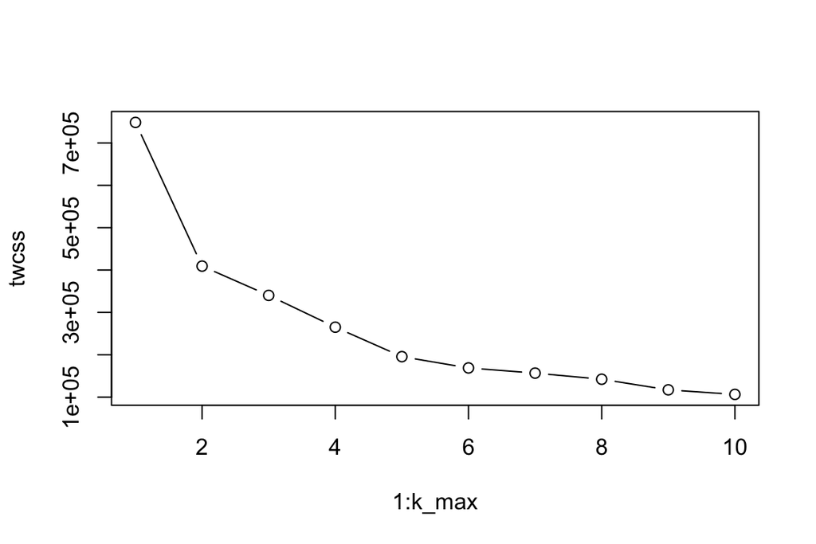

```r
set.seed(123) # to make sure different k's are comparable
k_max <- 10 # determine the max number of clusters

# calculate the total within sum of squares
twcss <- sapply(1:k_max, function(k){kmeans(dist_eu, k)$tot.withinss})

# visualize the results
plot(1:k_max, twcss, type='b')
```

WCSS plot shows that the optimal number of clusters in this dataset is 2: that is where the total sum drops clearly. Therefore we run the final k-means clustering with 2 centers and visualize it.

[figure not shown]

```r
# k-means clustering
km <-kmeans(dist_eu, centers = 2)

# plot the Boston dataset with clusters that didn't work out
# ggpairs(boston_scaledk, mapping = aes(col = cluster))

# plot the Boston dataset with clusters
pairs(boston_scaledk, col = km$cluster)
```

## Conclusion

### References:

(none)